# Lecture 3, Module 6: Stripcharts

Exercises

# Exercises

## Exercise 6.1: Basic stripchart

Make a stripchart for these values:
$$12.7,\ 23.8,\ 17.6,\ 45.2,\ 31.1,\ 26.9,\ 15.2$$

Make it look nice!

**Solution**

## Exercise 6.2: The `rivers` dataset

Let’s see a more real-world application of a stripchart.

The `rivers` dataset is a built-in vector in R that contains the lengths of the 141 major rivers in North America in miles.

For this exercise, make stripchart of the `rivers` dataset.

You should put in all the fancy stuff: include a main title and an $x$-axis title, adjust the range of the $x$ values on the horizontal axis, and make the points look nice.

Notice that there are now 141 points, so you’ll have make some judgements about the size of the points.

Finally, include jitter:

- Remember that you have to explicitly set the values for the $y$-axis to range from 0 to 2.
- Include the option `method = "jitter"`.
- Set the jitter amount to give a visually pleasing range for the points.

**Solution**

# Solutions to the Exercises

## Exercise 6.1: Basic stripchart

Make a stripchart for these values:
$$12.7, 23.8, 17.6, 45.2, 31.1, 26.9, 15.2$$

Make it look nice!

**Solution**

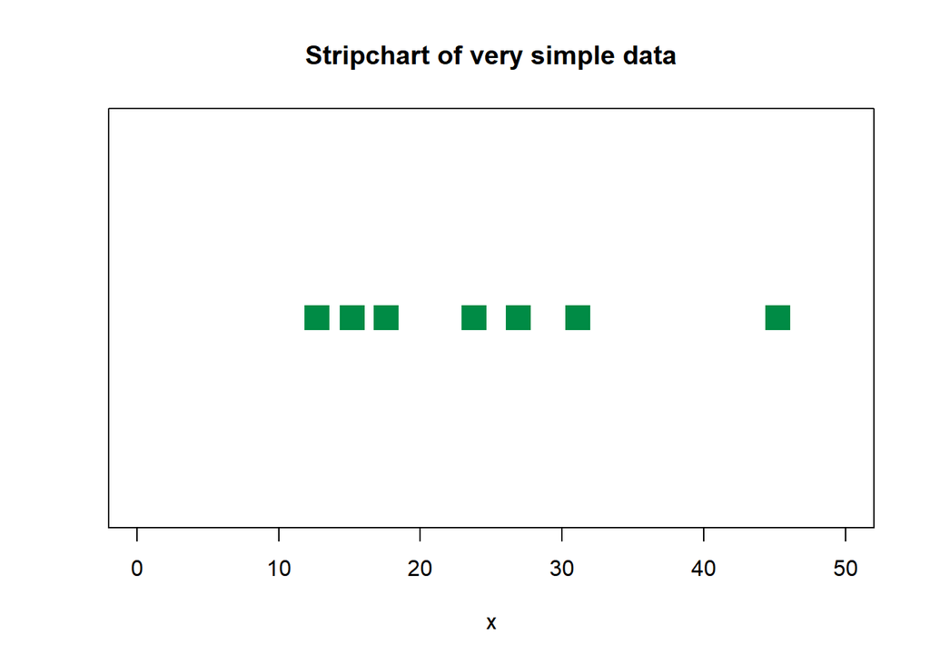

```r
exercise.6.1.numeric.vector <-
    c( 12.7, 23.8, 17.6, 45.2, 31.1, 26.9, 15.2 )

stripchart(
    exercise.6.1.numeric.vector,
    xlim = c(0, 50),
    main = "Stripchart of very simple data",
    xlab = "x",
    pch = 15,
    cex = 2.5,
    col = "springgreen4"
)
```

## Exercise 6.2: The `rivers` dataset

Let’s see a more real-world application of a stripchart.

The `rivers` dataset is a built-in vector in R that contains the lengths of the 141 major rivers in North America in miles.

For this exercise, make stripchart of the `rivers` dataset.

You should put in all the fancy stuff: include a main title and an $x$-axis title, adjust the range of the $x$ values on the horizontal axis, and make the points look nice.

Notice that there are now 141 points, so you’ll have make some judgements about the size of the points.

Finally, include jitter:

- Remember that you have to explicitly set the values for the $y$-axis to range from 0 to 2.
- Include the option `method = "jitter"`.
- Set the jitter amount to give a visually pleasing range for the points.

**Solution**

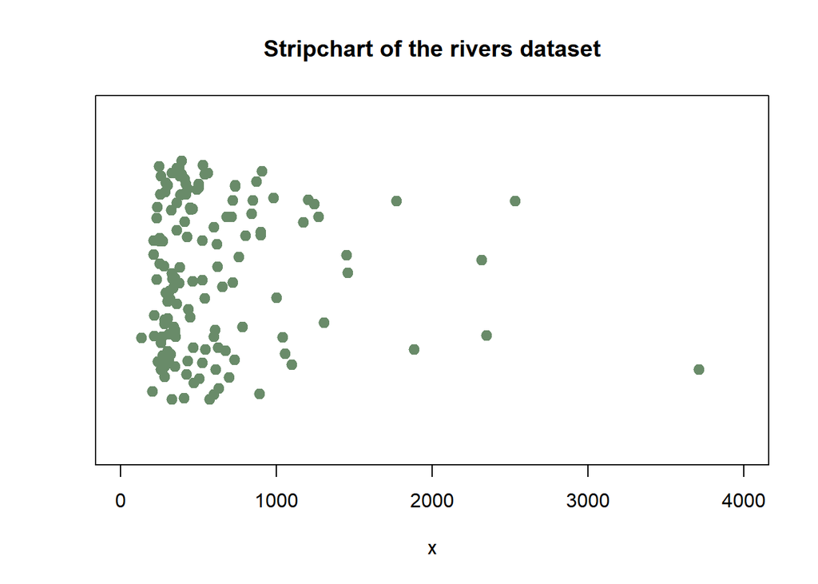

```r
stripchart(
    rivers,
    xlim = c(0, 4000),
    ylim = c(0, 2),
    main = "Stripchart of the rivers dataset",
    xlab = "x",
    method = "jitter",
    jitter = 0.7,
    pch = 19,
    cex = 1.2,
    col = "darkseagreen4"
)
```